# Exam 2

2018-06-24 18:09:34

**INSTRUCTIONS**

- Do not print out entire datasets!
- Use `ggplot` for all plotting (other than qqPlot).
- Put appropriate descriptive titles and labels on all plots.
- Do not include extraneous code; use only what is needed for the problem.
- Type non-code answers where you see ANSWER, not as comments in the code.

HINT: The keyboard shortcut to insert a pipe is CTRL + SHIFT + M (or CMD + SHIFT + M).

### PROBLEM 1

1. Create a contingency table to explore the relationship between these two variables.

```r
table(gayweed$marriage, gayweed$marijuana)
```

```
##
##       no yes
##   no  12   1
##   yes 15  22
```

```r
prop.table(table(gayweed$marriage, gayweed$marijuana))
```

```
##
##         no  yes
##   no  0.24 0.02
##   yes 0.30 0.44
```

2. Create a barplot to explore the relationship between these two variables.

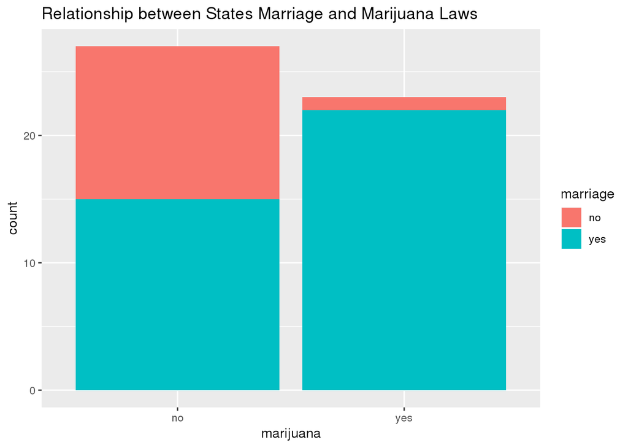

```r
ggplot(gayweed, aes(x = marijuana, fill = marriage)) +
  geom_bar() +
  ggtitle("Relationship between States Marriage and Marijuana Laws ")
```

3. Conduct a classical chi-square test of independence using R’s `chisq.test` function (set the parameter `correct = FALSE` to turn off the Yates correction).

```r
chisq.test(table(gayweed$marriage, gayweed$marijuana), correct = FALSE)
```

```
##
##  Pearson's Chi-squared test
##
## data:  table(gayweed$marriage, gayweed$marijuana)
## X-squared = 10.378, df = 1, p-value = 0.001275
```

4. Conduct a permutation test of independence. Print both the test statistic and the p-value. You do not have to plot your simulation results.

```r
chisq<-function(Obs){
  Exp <- outer(rowSums(Obs),colSums(Obs))/sum(Obs)
  sum((Obs-Exp)^2/Exp)
}


Observed <- table(gayweed$marriage, gayweed$marijuana)

testStatistic <- chisq(Observed)

Expected <- outer(rowSums(Observed),colSums(Observed))/sum(Observed)

weed <- gayweed$marijuana
marriage <- gayweed$marriage
set.seed(1)
alpha <- .05
N <- 10^4-1

randomChisq<-numeric(N)

for (i in 1:N){
  weedPerm <-sample(weed)
  randomTable <- table(marriage, weedPerm)
  randomChisq[i]<-chisq(randomTable)
}

pvalue <- (sum(randomChisq >= testStatistic) + 1) / (N + 1)
print(paste("The chi-square test statistic is ", round(testStatistic, 4), ".", sep=""), quote = F)
```

```
## [1] The chi-square test statistic is 10.3784.
```

```r
print(paste("The p-value for the test of independence is ", format(pvalue, scientific = F), ".", sep=""), quote=F)
```

```
## [1] The p-value for the test of independence is 0.0022.
```

5. Based on the permutation test, can you reject the null hypothesis at the α = 0.05 level of significance? If you reject the null hypothesis, use your exploratory data analysis in (A) and (B) to discuss the relationship between legal gay marriage and legal marijuana use.

ANSWER: The permutation test gave a pvalue of .0022 which is less than the chosen alpha giving evidence to reject the null hypothesis

6. Are the results in (C) and (D) consistent with one another (i.e., test statistics, p-values, conclusions)? What assumption must be met for the classical test that is not required for the permutation test?

ANSWER: The results are consistent with one another among all three variables (test statistic, p-values, and conclusions) For the chisq.test() the numbers must be big enough where in the permutation test this isnt neccesary.

### PROBLEM 2

In 2002, the New York Yankees had the highest average team salary among all MLB teams. However, was it statistically larger than the average salary of the rest of the teams in the league combined? (data: mlb2002.csv)

1. Use the `mutate` and `ifelse` functions to add a new variable to the dataset that identifies players according to whether they played for the New York Yankees (NYY) or some other team (OTH). Then use the `summarize` function to find n, mean, and standard deviation for salary in each group (NYY versus OTH).

```r
mlb02 <- mlb02OG %>%
  mutate(yankees = ifelse(team == "New York Yankees", "NYY", "OTH"), na.rm = TRUE) %>%
  group_by(yankees)

summary <- summarize(mlb02, n = mean(salary), sd = sd(salary) )
print(summary)
```

```
## # A tibble: 2 x 3
##   yankees        n       sd
##   <chr>      <dbl>    <dbl>
## 1 NYY     4342365. 4452166.
## 2 OTH     2315547. 2987632.
```

2. Create a boxplot to compare the NYY and OTH groups.

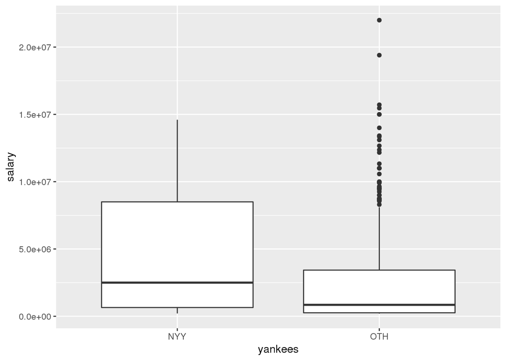

```r
ggplot(mlb02, aes(x = yankees, y = salary) ) +
  geom_boxplot()
```

3. Conduct a permutation test to determine whether the Yankees’ mean was statistically larger than the mean of the rest of the league. You do not have to plot your simulation results.

```r
teststat <- diff(summary$n)
print(teststat)
```

```
## [1] -2026817
```

```r
salarys   <- mlb02$salary



n_all          <- length(salarys)
n_yanks      <- as.numeric(filter(mlb02, yankees == "NYY") %>%
                              summarize(length(salary)))
```

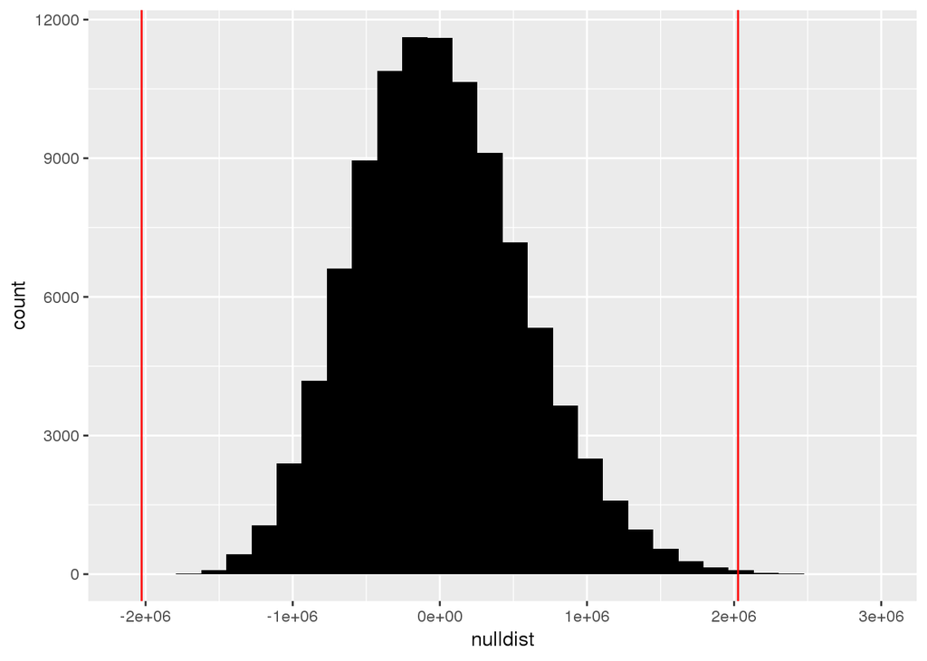

```r
set.seed(1)



alpha <- .05

N <- 10^5-1

diffs <- numeric(N)




for(i in 1:N){
  index <- sample(n_all, 29)
  diffs[i] <- mean(salarys[index]) - mean(salarys[-index])
  }



ggplot(data.frame(nulldist = diffs), aes(x = nulldist)) +
  geom_histogram(fill = "black") +
  geom_vline(xintercept = -1 * abs(teststat), color = "red") +
  geom_vline(xintercept = abs(teststat), color = "red")
```

```r
pLower <- sum(diffs <= -1*abs(teststat))
pupper <- sum(diffs >= abs(teststat))

pvalue <- (pLower + pupper + 1) / (N + 1)
print(pvalue)
```

```
## [1] 0.00102
```

```r
sprintf("The pvalue is %1.5f.", pvalue)
```

```
## [1] "The pvalue is 0.00102."
```

4. Conduct a classical two-sample t-test for the same hypotheses using R’s `t.test` function.

```r
t.test(mlb02$salary, mu = teststat)
```

```
##
##  One Sample t-test
##
## data:  mlb02$salary
## t = 41.902, df = 848, p-value < 2.2e-16
## alternative hypothesis: true mean is not equal to -2026817
## 95 percent confidence interval:
##  2178132 2591426
## sample estimates:
## mean of x
##   2384779
```

5. Based on the results of the permutation test, can we conclude at the α = 0.05 level of significance that the Yankee’s mean was statistically larger than the average salary of the rest of the teams in the league combined? If so, does the difference large enough to have practical significance, in context?

ANSWER: Yes the Pvalue of 0.00102 gives great evidence to reject the null hypsothesis yankees’s mean was statistically larger than the average salary of the rest of the leagueo

6. Given the classical two-sample t-test assumptions, why might the p-value from the test in (D) be unreliable for these data?

ANSWER: The p-value may be unreliable because t.test assumes that the data is normally distributed

### PROBLEM 3

Consider the flight delays dataset we have worked with in class. Use the information in the Delay variable and conduct a permutation test to determine whether the two carriers have different proportions of flights that are delayed (i.e., that depart late). Use the α = 0.05 to make your decision. If you do not reject the null hypothesis, report the overall proportion of flights that leave late. If you reject the null hypothesis, discuss the difference between the carriers. You do not have to plot your simulation results.

```r
flights <- flightsOG %>%
  mutate(isdelayed = Delay > 0, na.rm = TRUE) %>%
  group_by(Carrier)

summary <- summarize(flights,propdelayed = mean(isdelayed))
print(summary)
```

```
## # A tibble: 2 x 2
##   Carrier propdelayed
##   <fct>         <dbl>
## 1 AA            0.289
## 2 UA            0.357
```

```r
teststat <- diff(summary$propdelayed)

delayed <- flights$isdelayed

n_all   <- length(flights$ID)
n_UA   <- as.numeric(filter(flights, Carrier == "UA") %>%
                               summarize(length(Carrier)))


alpha <- .05

set.seed(1)

N <- 10^5-1


randomDiffs <- numeric(N)

for(i in 1:N){
  index <- sample(n_all, 1123)
  randomDiffs[i] <- mean(delayed[index]) - mean(delayed[-index])}



pLower <- sum(randomDiffs <= -1*abs(teststat))
pupper <- sum(randomDiffs >= abs(teststat))
pvalue <- (pLower + pupper + 1) / (N + 1)
print(pvalue)
```

```
## [1] 5e-05
```

ANSWER: With a pvalue much less than .05 (.00005) we reject the null hypothesis that on the proportion of delayed flights between carriers are the same. It seems on average United Airlines has a higher proportion of delayed flights.

### PROBLEM 4

Watauga County Schools frequently closes for inclement weather days. Missed days have to be made up later in the year. What is the distribution of total days missed? (data: wcsweatherdays.csv)

1. Make a histogram of total. What shape does the variable seem to have?

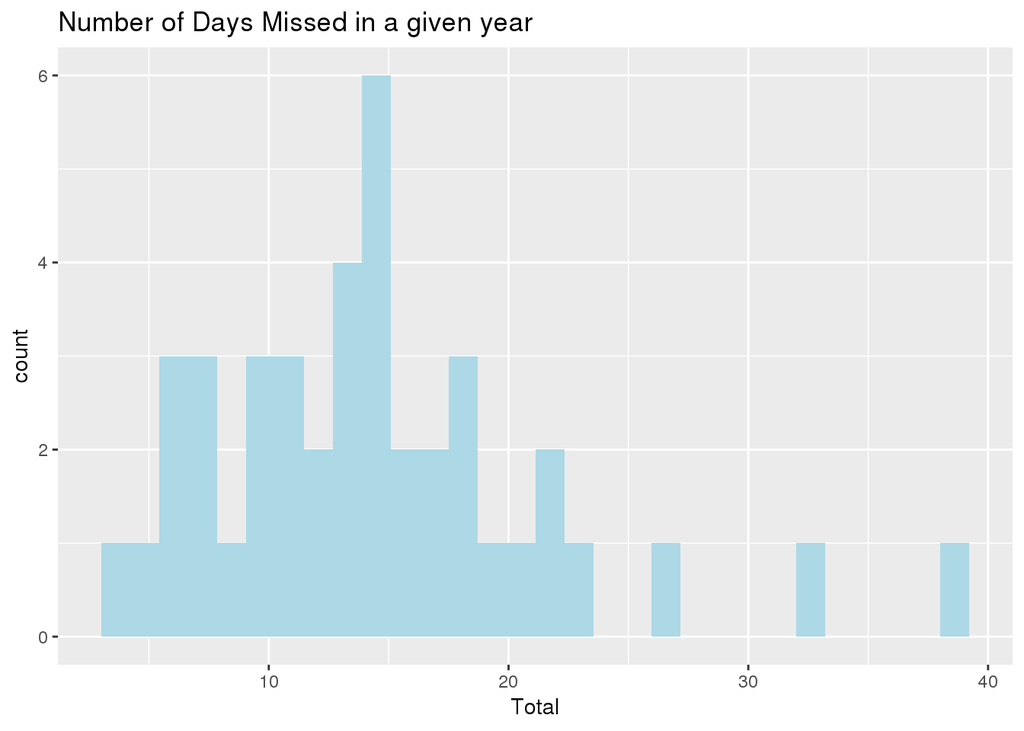

```r
ggplot(weatherdelays, aes(x = total)) +
  geom_histogram(fill = "lightblue") +
  xlab("Total") +
  ggtitle("Number of Days Missed in a given year")
```

ANSWER: The variable seems like it could be normal

2. For the total number of missed days per year, compute the upper fence for outliers.

```r
fivenum <- fivenum(weatherdelays$total)
iqr <- IQR(weatherdelays$total)
lower = fivenum[2] - 1.5 * iqr
upper = fivenum[4] + 1.5 * iqr

cat("Lower Fence =", lower, "Upper Fence =", upper)
```

```
## Lower Fence = -1.625 Upper Fence = 29.625
```

3. Filter the dataset and print out only the data for the years that are outliers.

```r
weatherdelays2 <- weatherdelays %>%
  filter(total >= upper) %>%
  print()
```

```
##        year aug sep oct nov dec jan feb mar apr may total snowinches
## 1 1976-1977   0   0   0   1   4  21   7   0   0   0    33       47.5
## 2 1977-1978   0   0   0   4   2  17  13   3   0   0    39       55.4
```

4. Filter the dataset to remove the outliers. Now assess total for normality using…
- skewness and kurtosis
- density, ECDF, and QQ plots
- chi-square goodness-of-fit test

```r
weatherdelays3 <- weatherdelays %>%
  filter(total <= upper)

m <- mean(weatherdelays3$total)
sd <- sd(weatherdelays3$total)

weatherdelays3 %>% summarize(skew = skewness(total),
                   kurt = kurtosis(total))
```

```
##        skew     kurt
## 1 0.2651115 2.531619
```

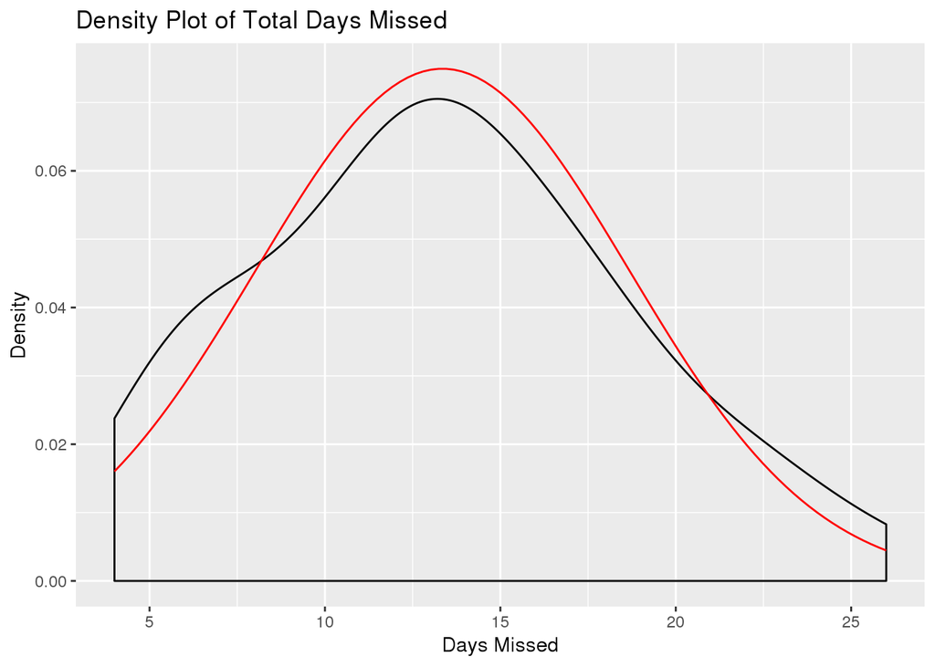

```r
ggplot(weatherdelays3, aes(x = total)) +
  geom_density() +
  ggtitle("Density Plot of Total Days Missed") +
  xlab("Days Missed") +
  ylab("Density")  +
  stat_function(fun = dnorm, args = list(m, sd), color = "red")
```

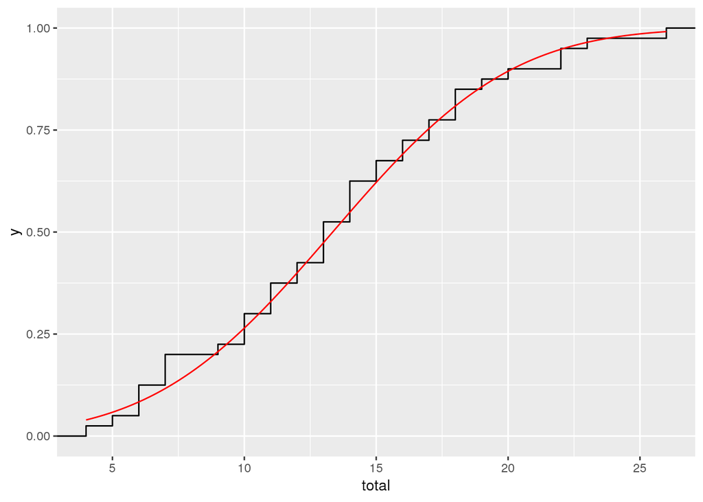

```r
ggplot(weatherdelays3, aes(x =total)) +
  stat_ecdf() +
  stat_function(fun = pnorm, args = list(m, sd), color = "red")
```

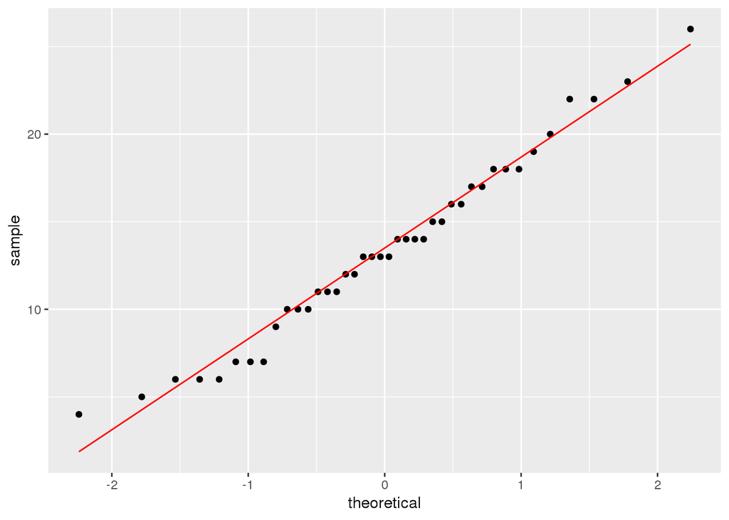

```r
ggplot(weatherdelays3, aes(sample = total)) +
  geom_qq() +
  geom_qq_line(color = "red")
```

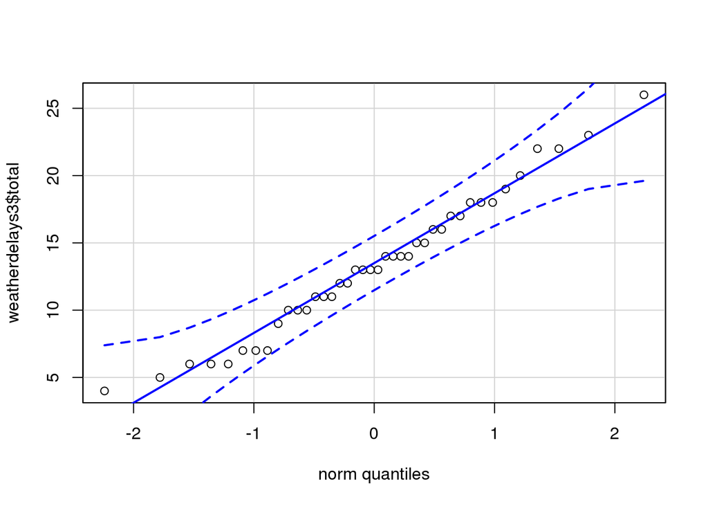

```r
qqPlot(weatherdelays3$total, id = FALSE)
```

```r
weatherdelays4 <- weatherdelays3 %>%
  mutate(zscore = (total - mean(total)) / sd(total))

pi1 <- pnorm(-2)
pi2 <- pnorm(-1) - pnorm(-2)
pi3 <- pnorm( 0) - pnorm(-1)
pi4 <- pnorm(+1) - pnorm( 0)
pi5 <- pnorm(+2) - pnorm(+1)
pi6 <- pnorm(+2, lower.tail=F)

normprobs <- c(pi1, pi2, pi3, pi4, pi5, pi6)
print(normprobs)
```

```
## [1] 0.02275013 0.13590512 0.34134475 0.34134475 0.13590512 0.02275013
```

```r
observed <- c(sum(weatherdelays4$zscore <= -2),
              sum(-2 < weatherdelays4$zscore & weatherdelays4$zscore <= -1),
              sum(-1 < weatherdelays4$zscore & weatherdelays4$zscore <=  0),
              sum( 0 < weatherdelays4$zscore & weatherdelays4$zscore <= +1),
              sum(+1 < weatherdelays4$zscore & weatherdelays4$zscore <= +2),
              sum(weatherdelays4$zscore > +2))

print(observed)
```

```
## [1]  0  8 13 13  5  1
```

```r
n <- sum(observed)

expected <- normprobs*n

chisq.test(observed, p = normprobs, simulate.p.value = TRUE)
```

```
##
##  Chi-squared test for given probabilities with simulated p-value
##  (based on 2000 replicates)
##
## data:  observed
## X-squared = 2.2256, df = NA, p-value = 0.8501
```

5. With the outliers removed, can we consider the distribution of total number of inclement weather days to be approximately normally? Support your answer with evidence from (D ).

### PROBLEM 5

Let’s come back to baseball salaries for a moment. Do the first digits of the salaries of Major League Baseball players in 2002 follow the Benford distribution?

1. Find the tables of observed and expected counts.

```r
mlb02firstdig <- mlb02OG %>%
  mutate(firstdigitsal = signifd(salary, 1))
observed <- table(mlb02firstdig$firstdigitsal)
print(observed)
```

```
##
##   1   2   3   4   5   6   7   8   9
## 116 321 110  75  60  58  45  39  25
```

```r
n <- sum(observed)
firstdigit   <- 1:9
benfordprobs <- log10(1+1/firstdigit)

expected <- benfordprobs * n
print(expected)
```

```
## [1] 255.57447 149.50148 106.07299  82.27660  67.22488  56.83782  49.23516
## [8]  43.42849  38.84811
```

```r
mlb200000 <- mlb02OG %>%
  filter(salary == 200000)
str(mlb200000)
```

```
## 'data.frame':    45 obs. of  7 variables:
##  $ last    : Factor w/ 702 levels "Abbott","Abernathy",..: 39 214 219 366 431 495 180 318 591 595 ...
##  $ first   : Factor w/ 364 levels "Aaron","Abraham",..: 277 218 132 289 238 50 118 318 161 184 ...
##  $ salary  : int  200000 200000 200000 200000 200000 200000 200000 200000 200000 200000 ...
##  $ league  : Factor w/ 2 levels "AL","NL": 1 1 1 1 1 1 1 1 1 1 ...
##  $ region  : Factor w/ 3 levels "Central","East",..: 2 2 2 2 2 2 2 2 2 2 ...
##  $ team    : Factor w/ 30 levels "Anaheim Angels",..: 4 4 4 4 4 5 28 28 28 28 ...
##  $ position: Factor w/ 8 levels "B1","B2","B3",..: 7 8 4 7 2 1 8 7 3 7 ...
```

2. Use the `chisq.test` function to conduct a goodness of fit test.

```r
chisq.test(observed, p = benfordprobs, simulate.p.value = TRUE)
```

```
##
##  Chi-squared test for given probabilities with simulated p-value
##  (based on 2000 replicates)
##
## data:  observed
## X-squared = 280.3, df = NA, p-value = 0.0004998
```

3. What can you conclude from (B)? Consider that the MLB league minimum salary in 2002 was $200,000. How would that help explain the results of your test?

### PROBLEM 6

In class we discussed a Zener card test for psychic ability. A person tries to guess the hidden symbol on cards that are presented to them one at a time. The cards are drawn with replacement from a deck containing five symbols in equal proprotions: square, circle, star, cross, and waves. In the online test we took in class, getting 10 or more correct on 25 guesses was considered evidence of psychic ability.

1. If someone is randomly guessing each time, what is the probability they get 10 or more correct out of 25?

```r
a <- pbinom(10,25, .2, lower.tail = FALSE)
print(a)
```

```
## [1] 0.00555492
```

2. Suppose the number of trials in the test was increased to 100 instead of 25. If we want the probability to be as close as possible to (A), how many correct guesses out of 100 would be considered evidence of psychic ability?

```r
x <- 1:100
correctguesses <- data.frame(guess = x, prob = round(pbinom(x, 100, .2, lower.tail = FALSE), digits = 5)) %>%
  filter(prob <= a)
print.data.frame(correctguesses)
```

```
##    guess    prob
## 1     31 0.00313
## 2     32 0.00155
## 3     33 0.00074
## 4     34 0.00034
## 5     35 0.00015
## 6     36 0.00006
## 7     37 0.00002
## 8     38 0.00001
## 9     39 0.00000
## 10    40 0.00000
## 11    41 0.00000
## 12    42 0.00000
## 13    43 0.00000
## 14    44 0.00000
```

[output cut: 56 more lines]

ANSWER: 31 guesses

3. If someone has some degree of psychic ability, then their chance of guessing correctly on each trial should be better than someone who is randomly guessing. Consider probabilities ranging from 0.2 to 0.9, in increments of 0.1. Create a plot that shows p = chance of guessing correctly on each trial (x axis) versus the probability of getting 10 or more cards correct out of 25 (y axis).

[figure not shown]

```r
X <- seq(0.2, .9, .1)
correctguesses <- data.frame(guessprob = X, prob = round(pbinom(10, 25, X, lower.tail = FALSE), digits = 5))

ggplot(correctguesses,aes(x = guessprob, y = prob)) +
  geom_line() +
  xlab("Probability of Guessing 10 or More") +
  ylab("Probability of Guessing 1 Correctly ")
```